# Data Science Milestone

NLP exploratory analysis

We use HC corpora data collected across English Twitter posts, blogs and news. To get insight into Natural Language Processing and eventually construct a prediction algorithm for the next word during typing (e.g. auto-suggestions on mobile devices).

We will use the following files:

| File | Lines | Words |
| --- | --- | --- |
| en_US.blogs.txt | 899288 | 37334114 |
| en_US.news.txt | 1010242 | 34365936 |
| en_US.twitter.txt | 2360148 | 30359804 |

The first step is to acquire and load the data. We obtain English Twitter files from Coursera Project webpage and in view of computational restrictions we choose a representative random subset of 10 thousand lines (using Linux sort -R command).

First we load the text using the following R code.

```r
#Representative subset of 10000 lines saved in test_file
fileName <- "test_file"
#Create file connection
con <- file(fileName, "r")
#Read all words
d <- scan(con, character(0))
# Close connection
close(con)
```

Next, we want to exclude profanity from the analysis. We created a text file with common English profanity words and load it into our R session.

```r
con <- file("bad_words", "r")
bad <- scan(con, character(0))
close(con)
```

For analysis we tokenize the text into words (excluding “bad” words), numbers and punctuation. We store those elements in 3 different vectors.

```r
d <- lapply(d, toupper)
bad <- lapply(bad, toupper)
words <- c(); numbers <- c(); puncts <- c()

for (i in (1:300000)){
  element <- d[[i]]
  word <- gsub("[^A-Z]+", "", element)
  good <-1
  if (word %in% bad) {good <-0}
  if ((word > 0)&good){words <- c(words, word)}
  number <- gsub("[^0-9]+", "", element)
  if (number > 0){numbers <- c(numbers, number)}
  pun <- gsub("[^[:punct:]]", "", element)
  if (nchar(pun) > 0){puncts <- c(puncts, pun)}
}
```

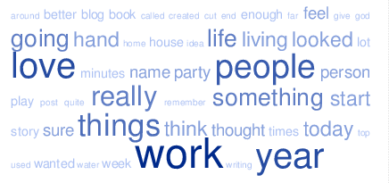

An interesting question is: what are the ten most common words in the dataset?

| word | times |
| --- | --- |
| THE | 14751 |
| AND | 8623 |
| TO | 8462 |
| A | 7202 |
| OF | 6953 |
| I | 6180 |
| IN | 4672 |
| THAT | 3763 |
| IS | 3439 |
| IT | 3194 |

These are common English particles. Let us look at the most used “long” words (more than 6 letters):

| word | times |
| --- | --- |
| BECAUSE | 467 |
| THROUGH | 282 |
| SOMETHING | 280 |
| ANOTHER | 247 |
| THOUGHT | 207 |
| WITHOUT | 155 |
| DIFFERENT | 153 |
| FRIENDS | 152 |
| GETTING | 148 |
| STARTED | 148 |

To understand how many words constitute the major part of the language, we plot the histogram of the frequencies of words.

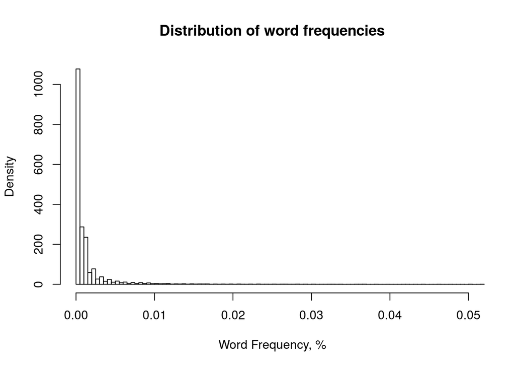

We observe that most of the words have low (<5%) frequency.

The following graph shows how many distinct words are necessary to cover a part of the text in percentage.

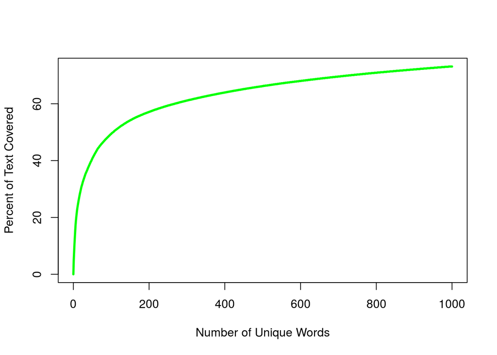

Many words tend to be used together, meaning that it is possible to give a prediction with high probability of the following word. For instance, let us look at the most common occurring word pairs.

| Words pair | Times |
| --- | --- |
| OF THE | 1409 |
| IN THE | 1219 |
| TO THE | 679 |
| ON THE | 600 |
| TO BE | 532 |
| AND THE | 462 |
| FOR THE | 462 |
| AND I | 448 |
| AT THE | 403 |
| IT WAS | 402 |
| I HAVE | 396 |
| IT IS | 373 |
| I WAS | 373 |
| IN A | 371 |
| IS A | 352 |
| I AM | 325 |
| WITH A | 321 |
| THAT I | 319 |
| WITH THE | 312 |
| OF A | 281 |
| FROM THE | 271 |
| IF YOU | 257 |
| THAT THE | 241 |
| THIS IS | 239 |
| ONE OF | 235 |
| WILL BE | 230 |
| IS THE | 227 |
| AS A | 226 |
| FOR A | 226 |
| YOU CAN | 223 |
| BY THE | 220 |
| OF MY | 218 |
| I HAD | 216 |
| BUT I | 214 |
| WAS A | 203 |
| ALL THE | 202 |
| HAVE A | 201 |
| WHEN I | 197 |
| A FEW | 196 |
| AND A | 196 |
| I THINK | 193 |
| HAVE BEEN | 191 |
| THE SAME | 190 |
| TO DO | 190 |
| GOING TO | 188 |
| HAVE TO | 188 |
| WANT TO | 187 |
| OUT OF | 184 |
| TO GET | 183 |
| TO MAKE | 179 |

We can also explore collocations of longer words (>3 characters).

[output not shown]

In the following publication we provide prediction algorithm for the next word during typesetting.